# Project 3 - Diamonds Dataset

Jumpei Fujimoto

# Description of Project

In this project, you will be working with the `diamonds` dataset. This dataset contains information for 53,940 diamonds sold in the US. Each diamond has ten features, but we will only be interested in the following five:

[output not shown]

Our goal will be to create a model for `price` using the remaining four variables listed as predictors.

# Part A: Load and Prepare the Data

You will need the `ggplot2` package for this project. Load it now.

```r
require(ggplot2)
```

The diamonds dataset is contained in the tab-separated file “diamonds.txt”. Read the dataset into a dataframe called `df`, and then print a summary of this dataframe.

```r
df <- read.table("diamonds.txt", sep="\t", header=TRUE)
summary(df)
```

```
     carat               cut        color        clarity          depth           table           price             x
 Min.   :0.2000   Fair     : 1610   D: 6775   SI1    :13065   Min.   :43.00   Min.   :43.00   Min.   :  326   Min.   : 0.000
 1st Qu.:0.4000   Good     : 4906   E: 9797   VS2    :12258   1st Qu.:61.00   1st Qu.:56.00   1st Qu.:  950   1st Qu.: 4.710
 Median :0.7000   Ideal    :21551   F: 9542   SI2    : 9194   Median :61.80   Median :57.00   Median : 2401   Median : 5.700
 Mean   :0.7979   Premium  :13791   G:11292   VS1    : 8171   Mean   :61.75   Mean   :57.46   Mean   : 3933   Mean   : 5.731
 3rd Qu.:1.0400   Very Good:12082   H: 8304   VVS2   : 5066   3rd Qu.:62.50   3rd Qu.:59.00   3rd Qu.: 5324   3rd Qu.: 6.540
 Max.   :5.0100                     I: 5422   VVS1   : 3655   Max.   :79.00   Max.   :95.00   Max.   :18823   Max.   :10.740
                                    J: 2808   (Other): 2531
       y                z
 Min.   : 0.000   Min.   : 0.000
 1st Qu.: 4.720   1st Qu.: 2.910
 Median : 5.710   Median : 3.530
 Mean   : 5.735   Mean   : 3.539
 3rd Qu.: 6.540   3rd Qu.: 4.040
 Max.   :58.900   Max.   :31.800
```

The variables `cut`, `color`, and `clarity` are factor (categorical/qualitative) variables. By default, R sets the levels for such variables to be alphabetical. However, the levels for each of these variables have an inherent ranking that is not consistent with an alphabetical ordering. To illustrate this point, run the following code chunk to see the current ordering for the levels of each of these variables, and compare these orders to the ones provided at the beginning of this document.

```r
list(
  cut_levels = levels(df$cut),
  color_levels = levels(df$color),
  clarity_level = levels(df$clarity)
)
```

```
$cut_levels
[1] "Fair"      "Good"      "Ideal"     "Premium"   "Very Good"

$color_levels
[1] "D" "E" "F" "G" "H" "I" "J"

$clarity_level
[1] "I1"   "IF"   "SI1"  "SI2"  "VS1"  "VS2"  "VVS1" "VVS2"
```

To avoid any potential confusion, we will explicitly set the levels for each of these variables to be in increasing order of quality. Replace the blank lines in the code chunk below with a list of levels for each variable, from worst to best. You will need to surround each level name with quotation marks. Separate the levels by commas.

```r
df$cut <- factor(df$cut, levels=c("Fair", "Good", "Very Good", "Premium", "Ideal"))
df$color <- factor(df$color, levels = c("J", "I", "H", "G", "E", "D"))
df$clarity <- factor(df$clarity, levels=c("I1", "SI2", "SI1", "VS2", "VS1", "VVS2", "VVS1", "IF"))
```

Run the cell below to confirm that the levels for the factor variables are now in the correct order.

```r
list(
  cut_levels = levels(df$cut),
  color_levels = levels(df$color),
  clarity_level = levels(df$clarity)
)
```

```
$cut_levels
[1] "Fair"      "Good"      "Very Good" "Premium"   "Ideal"

$color_levels
[1] "J" "I" "H" "G" "E" "D"

$clarity_level
[1] "I1"   "SI2"  "SI1"  "VS2"  "VS1"  "VVS2" "VVS1" "IF"
```

# Part B: Exploratory Plots

Use `ggplot()` to create a scatter plot plotting `price` against `carat`. Color the points by `clarity` and set an alpha level of 0.6.

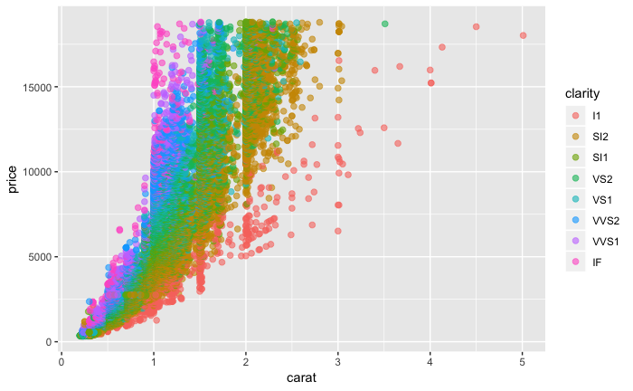

```r
ggplot(df, aes(y = price, x = carat, col = clarity)) +
  geom_point(alpha = 0.6, size = 2)
```

We saw in class that the relationship between `price` and `carat` turned out to be approximately linear after a log-log transformation. Recreate the plot from above, replacing these two variables with their natural logarithms.

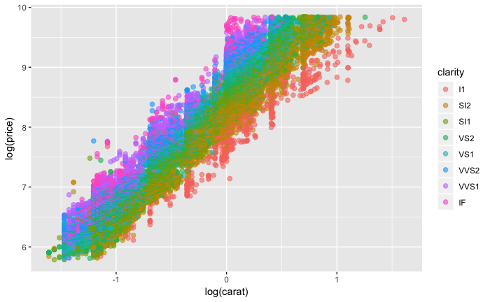

```r
ggplot(df, aes(y = log(price), x = log(carat), col = clarity)) +
  geom_point(alpha = 0.6, size = 2)
```

Recreate the previous plot, but add a facet grid by appending the following code to the end of your ggplot command: `+ facet_grid(color~cut)`.

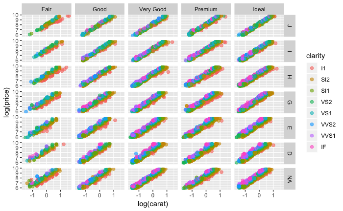

```r
ggplot(df, aes(y = log(price), x = log(carat), col = clarity)) +
  geom_point(alpha = 0.6, size = 2) + facet_grid(color~cut)
```

# Part C: Create the Model

Create a regression model using the logarithm of `price` as the response. The predictors should be `cut`, `color`, `clarity`, and the logarithm of `carat`. Display a summary of your model.

```r
s1 <-lm(log(price) ~ cut + color + clarity + log(carat), data =df)
summary(s1)
```

```
Call:
lm(formula = log(price) ~ cut + color + clarity + log(carat),
    data = df)

Residuals:
     Min       1Q   Median       3Q      Max
-1.00353 -0.08564  0.00022  0.08277  1.40796

Coefficients:
             Estimate Std. Error t value Pr(>|t|)
(Intercept)  7.344158   0.006586 1115.11   <2e-16 ***
cutGood      0.086422   0.004325   19.98   <2e-16 ***
cutVery Good 0.120906   0.004024   30.05   <2e-16 ***
cutPremium   0.143720   0.003978   36.13   <2e-16 ***
cutIdeal     0.164641   0.003948   41.70   <2e-16 ***
colorI       0.137881   0.003113   44.29   <2e-16 ***
colorH       0.258381   0.002939   87.93   <2e-16 ***
colorG       0.350111   0.002864  122.22   <2e-16 ***
colorE       0.453478   0.002939  154.31   <2e-16 ***
colorD       0.506596   0.003082  164.35   <2e-16 ***
claritySI2   0.433701   0.005757   75.33   <2e-16 ***
claritySI1   0.596032   0.005726  104.09   <2e-16 ***
clarityVS2   0.734718   0.005759  127.57   <2e-16 ***
clarityVS1   0.807343   0.005844  138.15   <2e-16 ***
clarityVVS2  0.936688   0.006030  155.33   <2e-16 ***
clarityVVS1  1.003900   0.006209  161.68   <2e-16 ***
clarityIF    1.098943   0.006735  163.16   <2e-16 ***
log(carat)   1.876446   0.001231 1524.64   <2e-16 ***
---
Signif. codes:  0 '***' 0.001 '**' 0.01 '*' 0.05 '.' 0.1 ' ' 1

Residual standard error: 0.1336 on 44380 degrees of freedom
  (9542 observations deleted due to missingness)
Multiple R-squared:  0.983, Adjusted R-squared:  0.983
F-statistic: 1.51e+05 on 17 and 44380 DF,  p-value: < 2.2e-16
```

**Based solely on the summary output above, does this model look good? Why or why not? Do you have any concerns about the model?**

It looks good because low p- value, good R-squared value and t- value is large enough.